# STAA 577: Laboratory Six Subset selection (`tidyverse`)

Adapted by Tavener & Field From: James, Witten, Hastie and Tibshirani

5 December 2018

### Load necessary libraries

```r
options(warnPartialMatchArgs = FALSE)  # don't want these warnings
library(magrittr)     # pipes
library(tibble)       # tibbles
library(dplyr)        # data wrangling
library(boot)         # for `cv.glm`
library(purrr)        # iteration
library(ggplot2)      # tidy plotting
library(ISLR)         # Hitters data set
library(leaps)        # step-wise model selection
library(gridExtra)    # arranging ggplots into grids
library(glmnet)       # logistic regression models
```

# 1 The `Hitters` Data Set

```r
# Explore data set
Hitters %<>% as.tibble()      # Convert to tibble
names(Hitters)                # Variable names
```

```
 [1] "AtBat"     "Hits"      "HmRun"     "Runs"      "RBI"       "Walks"     "Years"
 [8] "CAtBat"    "CHits"     "CHmRun"    "CRuns"     "CRBI"      "CWalks"    "League"
[15] "Division"  "PutOuts"   "Assists"   "Errors"    "Salary"    "NewLeague"
```

```r
Hitters                       # View the tibble; 322 observations
```

|  | AtBat | Hits | HmRun | Runs | RBI | Walks | Years | CAtBat | CHits | CHmRun | CRuns | CRBI | CWalks | League | Division | PutOuts | Assists | Errors | Salary | NewLeague |
| --- | --- | --- | --- | --- | --- | --- | --- | --- | --- | --- | --- | --- | --- | --- | --- | --- | --- | --- | --- | --- |
| 1 | 293 | 66 | 1 | 30 | 29 | 14 | 1 | 293 | 66 | 1 | 30 | 29 | 14 | A | E | 446 | 33 | 20 | NA | A |
| 2 | 315 | 81 | 7 | 24 | 38 | 39 | 14 | 3449 | 835 | 69 | 321 | 414 | 375 | N | W | 632 | 43 | 10 | 475.000 | N |
| 3 | 479 | 130 | 18 | 66 | 72 | 76 | 3 | 1624 | 457 | 63 | 224 | 266 | 263 | A | W | 880 | 82 | 14 | 480.000 | A |
| 4 | 496 | 141 | 20 | 65 | 78 | 37 | 11 | 5628 | 1575 | 225 | 828 | 838 | 354 | N | E | 200 | 11 | 3 | 500.000 | N |
| 5 | 321 | 87 | 10 | 39 | 42 | 30 | 2 | 396 | 101 | 12 | 48 | 46 | 33 | N | E | 805 | 40 | 4 | 91.500 | N |
| 6 | 594 | 169 | 4 | 74 | 51 | 35 | 11 | 4408 | 1133 | 19 | 501 | 336 | 194 | A | W | 282 | 421 | 25 | 750.000 | A |
| 7 | 185 | 37 | 1 | 23 | 8 | 21 | 2 | 214 | 42 | 1 | 30 | 9 | 24 | N | E | 76 | 127 | 7 | 70.000 | A |
| 8 | 298 | 73 | 0 | 24 | 24 | 7 | 3 | 509 | 108 | 0 | 41 | 37 | 12 | A | W | 121 | 283 | 9 | 100.000 | A |
| 9 | 323 | 81 | 6 | 26 | 32 | 8 | 2 | 341 | 86 | 6 | 32 | 34 | 8 | N | W | 143 | 290 | 19 | 75.000 | N |
| 10 | 401 | 92 | 17 | 49 | 66 | 65 | 13 | 5206 | 1332 | 253 | 784 | 890 | 866 | A | E | 0 | 0 | 0 | 1100.000 | A |

[output cut: 312 more lines]

```r
sum(is.na(Hitters$Salary))    # There are 59 observations without Salary info
```

```
[1] 59
```

```r
Hitters %<>% na.omit()        # Remove observations without salary information
nrow(Hitters)                 # 263 observations remaining
```

```
[1] 263
```

```r
sum(is.na(Hitters$Salary))    # All entries have salary information
```

```
[1] 0
```

# 2 Subset Selection

## 2.1 Exhaustive subset selection

The `leaps::regsubsets` function performs an exhaustive search for the best subsets of the variables in `x` for predicting `y` in a Linear Regression setting, using an efficient branch-and-bound algorithm. It chooses the best subset based on RSS. See `?leaps::regsubsets`.

```r
# Default value for NVMAX (maximum number of variables) is 8
regfit_full8 <- leaps::regsubsets(Salary ~ ., Hitters)
reg_summary8 <- summary(regfit_full8)
names(reg_summary8)
```

```
[1] "which"  "rsq"    "rss"    "adjr2"  "cp"     "bic"    "outmat" "obj"
```

```r
reg_summary8$obj
```

```
Subset selection object
Call: regsubsets.formula(Salary ~ ., Hitters)
19 Variables  (and intercept)
           Forced in Forced out
AtBat          FALSE      FALSE
Hits           FALSE      FALSE
HmRun          FALSE      FALSE
Runs           FALSE      FALSE
RBI            FALSE      FALSE
Walks          FALSE      FALSE
Years          FALSE      FALSE
CAtBat         FALSE      FALSE
CHits          FALSE      FALSE
CHmRun         FALSE      FALSE
CRuns          FALSE      FALSE
CRBI           FALSE      FALSE
CWalks         FALSE      FALSE
LeagueN        FALSE      FALSE
DivisionW      FALSE      FALSE
PutOuts        FALSE      FALSE
Assists        FALSE      FALSE
Errors         FALSE      FALSE
NewLeagueN     FALSE      FALSE
1 subsets of each size up to 8
Selection Algorithm: exhaustive
```

```r
# Repeat with all 19 variables
regfit_full <- leaps::regsubsets(Salary ~ ., data = Hitters, nvmax = 19)
reg_summary <- summary(regfit_full)
names(reg_summary)
```

```
[1] "which"  "rsq"    "rss"    "adjr2"  "cp"     "bic"    "outmat" "obj"
```

```r
reg_summary$obj
```

```
Subset selection object
Call: regsubsets.formula(Salary ~ ., data = Hitters, nvmax = 19)
19 Variables  (and intercept)
           Forced in Forced out
AtBat          FALSE      FALSE
Hits           FALSE      FALSE
HmRun          FALSE      FALSE
Runs           FALSE      FALSE
RBI            FALSE      FALSE
Walks          FALSE      FALSE
Years          FALSE      FALSE
CAtBat         FALSE      FALSE
CHits          FALSE      FALSE
CHmRun         FALSE      FALSE
CRuns          FALSE      FALSE
CRBI           FALSE      FALSE
CWalks         FALSE      FALSE
LeagueN        FALSE      FALSE
DivisionW      FALSE      FALSE
PutOuts        FALSE      FALSE
Assists        FALSE      FALSE
Errors         FALSE      FALSE
NewLeagueN     FALSE      FALSE
1 subsets of each size up to 19
Selection Algorithm: exhaustive
```

View the results, both as a `tibble` and graphically with `ggplot2::qplot()`:

```r
# View the model performance metrics for each size model
# Note: tibble() allows for non-standard characters as headers (e.g. '-' or spaces)
tibble::tibble(
  RSS = reg_summary$rss,
  `R-squared` = reg_summary$rsq,
  `Adj_R-squared` = reg_summary$adjr2,
  CP = reg_summary$cp,
  BIC = reg_summary$bic
)
```

| RSS | R-squared | Adj_R-squared | CP | BIC |
| --- | --- | --- | --- | --- |
| 36179679 | 0.3214501 | 0.3188503 | 104.281319 | -90.84637 |
| 30646560 | 0.4252237 | 0.4208024 | 50.723090 | -128.92622 |
| 29249297 | 0.4514294 | 0.4450753 | 38.693127 | -135.62693 |
| 27970852 | 0.4754067 | 0.4672734 | 27.856220 | -141.80892 |
| 27149899 | 0.4908036 | 0.4808971 | 21.613011 | -144.07143 |
| 26194904 | 0.5087146 | 0.4972001 | 14.023870 | -147.91690 |
| 25906548 | 0.5141227 | 0.5007849 | 13.128474 | -145.25594 |
| 25136930 | 0.5285569 | 0.5137083 | 7.400719 | -147.61525 |
| 24814051 | 0.5346124 | 0.5180572 | 6.158685 | -145.44316 |
| 24500402 | 0.5404950 | 0.5222606 | 5.009317 | -143.21651 |

[output cut: 9 more lines]

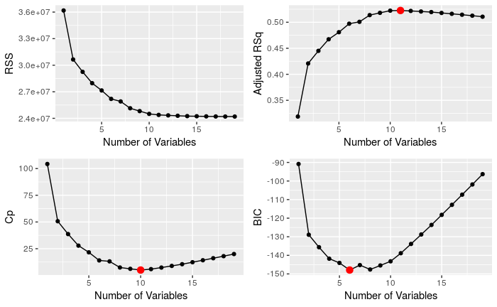

```r
# RSS
p_rss <- qplot(seq_along(reg_summary$rss), reg_summary$rss,
      xlab = "Number of Variables", ylab = "RSS") +
  geom_line()

# Adjusted R^2
pt_adjr2 <- which.max(reg_summary$adjr2)   # index of max feature
p_adjr2  <- qplot(seq_along(reg_summary$adjr2), reg_summary$adjr2,
                  xlab = "Number of Variables", ylab = "Adjusted RSq") +
  geom_line() +
  geom_point(aes(x = pt_adjr2, y = reg_summary$adjr2[pt_adjr2]),
             colour = "red", size = 3)
# CP
pt_cp <- which.min(reg_summary$cp)   # index of min feature
p_cp  <- qplot(seq_along(reg_summary$cp), reg_summary$cp,
               xlab = "Number of Variables", ylab = "Cp") +
  geom_line() +
  geom_point(aes(x = pt_cp, y = reg_summary$cp[pt_cp]),
             colour = "red", size = 3)

pt_bic <- which.min(reg_summary$bic)
p_bic  <- qplot(seq_along(reg_summary$bic), reg_summary$bic,
                xlab = "Number of Variables", ylab = "BIC") +
  geom_line() +
  geom_point(aes(x = pt_bic, y = reg_summary$bic[pt_bic]),
             colour = "red", size = 3)

# All 4 plots stored in variable `reg_plots`
# Plot in a grid
gridExtra::grid.arrange(p_rss,
                        p_adjr2,
                        p_cp,
                        p_bic, ncol = 2)
```

The `leaps` package has a (rather ugly) built in S3 plot method (sorry, no `ggplot`) for class `regsubsets` which you should consider by viewing “horizontally”. It displays the selected variables for a given value of model selection statistic. See `?plot.regsubsets`.

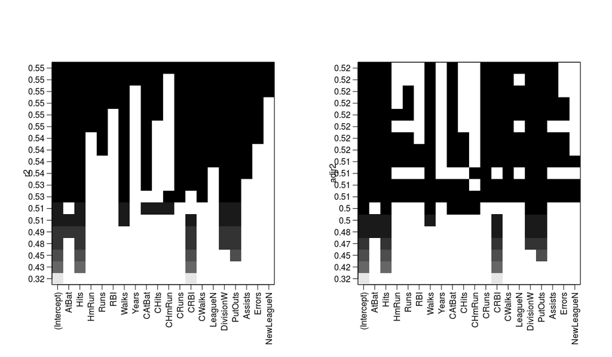

```r
par(mfrow = c(1, 2))
par(mgp = c(2, 0.75, 0))
plot(regfit_full, scale = "r2")
plot(regfit_full, scale = "adjr2")
```

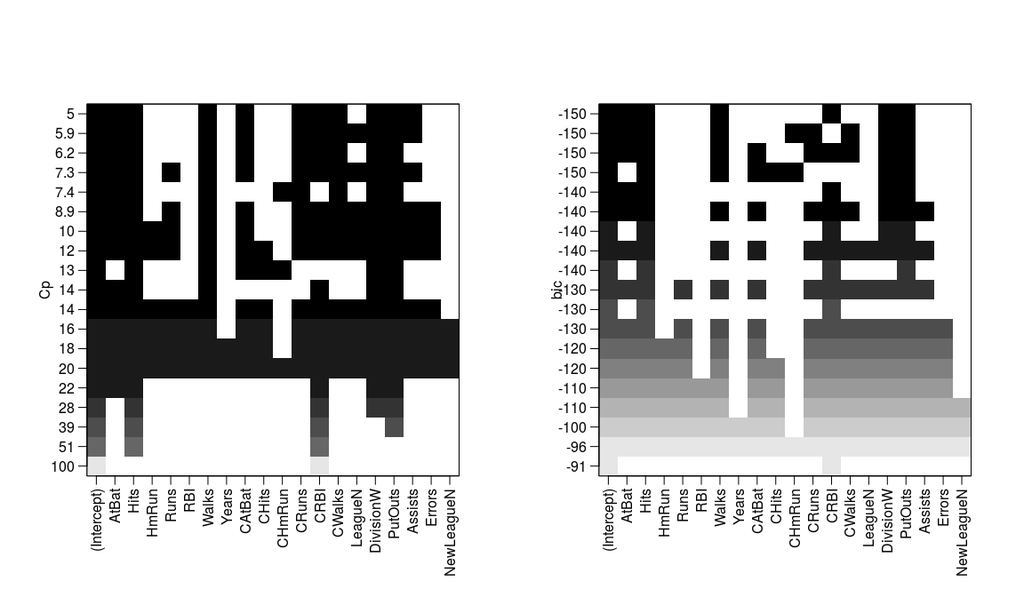

```r
par(mfrow = c(1, 2))
par(mgp = c(2, 0.75, 0))
plot(regfit_full, scale = "Cp")
plot(regfit_full, scale = "bic")
```

```r
coef(regfit_full, 6)   # Look at top 6 features; see ?coef::regsubsets, the `id =` argument
```

```
 (Intercept)        AtBat         Hits        Walks         CRBI    DivisionW      PutOuts
  91.5117981   -1.8685892    7.6043976    3.6976468    0.6430169 -122.9515338    0.2643076
```

```r
coef(regfit_full, 10)  # Look at top 10 features
```

```
 (Intercept)        AtBat         Hits        Walks       CAtBat        CRuns         CRBI
 162.5354420   -2.1686501    6.9180175    5.7732246   -0.1300798    1.4082490    0.7743122
      CWalks    DivisionW      PutOuts      Assists
  -0.8308264 -112.3800575    0.2973726    0.2831680
```

## 2.2 Forward and Backward Step-wise Selection

```r
regfit_fwd <- leaps::regsubsets(Salary ~ ., data = Hitters,
                                nvmax = 19, method = "forward")
summary(regfit_fwd)
```

```
Subset selection object
Call: regsubsets.formula(Salary ~ ., data = Hitters, nvmax = 19, method = "forward")
19 Variables  (and intercept)
           Forced in Forced out
AtBat          FALSE      FALSE
Hits           FALSE      FALSE
HmRun          FALSE      FALSE
Runs           FALSE      FALSE
RBI            FALSE      FALSE
Walks          FALSE      FALSE
Years          FALSE      FALSE
CAtBat         FALSE      FALSE
CHits          FALSE      FALSE
CHmRun         FALSE      FALSE
CRuns          FALSE      FALSE
CRBI           FALSE      FALSE
CWalks         FALSE      FALSE
LeagueN        FALSE      FALSE
DivisionW      FALSE      FALSE
PutOuts        FALSE      FALSE
Assists        FALSE      FALSE
Errors         FALSE      FALSE
NewLeagueN     FALSE      FALSE
1 subsets of each size up to 19
Selection Algorithm: forward
          AtBat Hits HmRun Runs RBI Walks Years CAtBat CHits CHmRun CRuns CRBI CWalks
1  ( 1 )  " "   " "  " "   " "  " " " "   " "   " "    " "   " "    " "   "*"  " "
2  ( 1 )  " "   "*"  " "   " "  " " " "   " "   " "    " "   " "    " "   "*"  " "
3  ( 1 )  " "   "*"  " "   " "  " " " "   " "   " "    " "   " "    " "   "*"  " "
4  ( 1 )  " "   "*"  " "   " "  " " " "   " "   " "    " "   " "    " "   "*"  " "
5  ( 1 )  "*"   "*"  " "   " "  " " " "   " "   " "    " "   " "    " "   "*"  " "
6  ( 1 )  "*"   "*"  " "   " "  " " "*"   " "   " "    " "   " "    " "   "*"  " "
7  ( 1 )  "*"   "*"  " "   " "  " " "*"   " "   " "    " "   " "    " "   "*"  "*"
8  ( 1 )  "*"   "*"  " "   " "  " " "*"   " "   " "    " "   " "    "*"   "*"  "*"
9  ( 1 )  "*"   "*"  " "   " "  " " "*"   " "   "*"    " "   " "    "*"   "*"  "*"
10  ( 1 ) "*"   "*"  " "   " "  " " "*"   " "   "*"    " "   " "    "*"   "*"  "*"
11  ( 1 ) "*"   "*"  " "   " "  " " "*"   " "   "*"    " "   " "    "*"   "*"  "*"
12  ( 1 ) "*"   "*"  " "   "*"  " " "*"   " "   "*"    " "   " "    "*"   "*"  "*"
13  ( 1 ) "*"   "*"  " "   "*"  " " "*"   " "   "*"    " "   " "    "*"   "*"  "*"
14  ( 1 ) "*"   "*"  "*"   "*"  " " "*"   " "   "*"    " "   " "    "*"   "*"  "*"
```

[output cut: 10 more lines]

```
5  ( 1 )  " "     "*"       "*"     " "     " "    " "
6  ( 1 )  " "     "*"       "*"     " "     " "    " "
7  ( 1 )  " "     "*"       "*"     " "     " "    " "
8  ( 1 )  " "     "*"       "*"     " "     " "    " "
9  ( 1 )  " "     "*"       "*"     " "     " "    " "
10  ( 1 ) " "     "*"       "*"     "*"     " "    " "
11  ( 1 ) "*"     "*"       "*"     "*"     " "    " "
12  ( 1 ) "*"     "*"       "*"     "*"     " "    " "
13  ( 1 ) "*"     "*"       "*"     "*"     "*"    " "
14  ( 1 ) "*"     "*"       "*"     "*"     "*"    " "
15  ( 1 ) "*"     "*"       "*"     "*"     "*"    " "
16  ( 1 ) "*"     "*"       "*"     "*"     "*"    " "
17  ( 1 ) "*"     "*"       "*"     "*"     "*"    "*"
18  ( 1 ) "*"     "*"       "*"     "*"     "*"    "*"
19  ( 1 ) "*"     "*"       "*"     "*"     "*"    "*"
```

```r
#regfit.fwd[2]
#regfit.fwd[[2]]
regfit_bwd <- leaps::regsubsets(Salary ~ ., data = Hitters,
                                nvmax = 19, method = "backward")
summary(regfit_bwd)
```

```
Subset selection object
Call: regsubsets.formula(Salary ~ ., data = Hitters, nvmax = 19, method = "backward")
19 Variables  (and intercept)
           Forced in Forced out
AtBat          FALSE      FALSE
Hits           FALSE      FALSE
HmRun          FALSE      FALSE
Runs           FALSE      FALSE
RBI            FALSE      FALSE
Walks          FALSE      FALSE
Years          FALSE      FALSE
CAtBat         FALSE      FALSE
CHits          FALSE      FALSE
CHmRun         FALSE      FALSE
CRuns          FALSE      FALSE
CRBI           FALSE      FALSE
CWalks         FALSE      FALSE
LeagueN        FALSE      FALSE
DivisionW      FALSE      FALSE
PutOuts        FALSE      FALSE
Assists        FALSE      FALSE
Errors         FALSE      FALSE
NewLeagueN     FALSE      FALSE
1 subsets of each size up to 19
Selection Algorithm: backward
          AtBat Hits HmRun Runs RBI Walks Years CAtBat CHits CHmRun CRuns CRBI CWalks
1  ( 1 )  " "   " "  " "   " "  " " " "   " "   " "    " "   " "    "*"   " "  " "
2  ( 1 )  " "   "*"  " "   " "  " " " "   " "   " "    " "   " "    "*"   " "  " "
3  ( 1 )  " "   "*"  " "   " "  " " " "   " "   " "    " "   " "    "*"   " "  " "
4  ( 1 )  "*"   "*"  " "   " "  " " " "   " "   " "    " "   " "    "*"   " "  " "
5  ( 1 )  "*"   "*"  " "   " "  " " "*"   " "   " "    " "   " "    "*"   " "  " "
6  ( 1 )  "*"   "*"  " "   " "  " " "*"   " "   " "    " "   " "    "*"   " "  " "
7  ( 1 )  "*"   "*"  " "   " "  " " "*"   " "   " "    " "   " "    "*"   " "  "*"
8  ( 1 )  "*"   "*"  " "   " "  " " "*"   " "   " "    " "   " "    "*"   "*"  "*"
9  ( 1 )  "*"   "*"  " "   " "  " " "*"   " "   "*"    " "   " "    "*"   "*"  "*"
10  ( 1 ) "*"   "*"  " "   " "  " " "*"   " "   "*"    " "   " "    "*"   "*"  "*"
11  ( 1 ) "*"   "*"  " "   " "  " " "*"   " "   "*"    " "   " "    "*"   "*"  "*"
12  ( 1 ) "*"   "*"  " "   "*"  " " "*"   " "   "*"    " "   " "    "*"   "*"  "*"
13  ( 1 ) "*"   "*"  " "   "*"  " " "*"   " "   "*"    " "   " "    "*"   "*"  "*"
14  ( 1 ) "*"   "*"  "*"   "*"  " " "*"   " "   "*"    " "   " "    "*"   "*"  "*"
```

[output cut: 10 more lines]

```
5  ( 1 )  " "     " "       "*"     " "     " "    " "
6  ( 1 )  " "     "*"       "*"     " "     " "    " "
7  ( 1 )  " "     "*"       "*"     " "     " "    " "
8  ( 1 )  " "     "*"       "*"     " "     " "    " "
9  ( 1 )  " "     "*"       "*"     " "     " "    " "
10  ( 1 ) " "     "*"       "*"     "*"     " "    " "
11  ( 1 ) "*"     "*"       "*"     "*"     " "    " "
12  ( 1 ) "*"     "*"       "*"     "*"     " "    " "
13  ( 1 ) "*"     "*"       "*"     "*"     "*"    " "
14  ( 1 ) "*"     "*"       "*"     "*"     "*"    " "
15  ( 1 ) "*"     "*"       "*"     "*"     "*"    " "
16  ( 1 ) "*"     "*"       "*"     "*"     "*"    " "
17  ( 1 ) "*"     "*"       "*"     "*"     "*"    "*"
18  ( 1 ) "*"     "*"       "*"     "*"     "*"    "*"
19  ( 1 ) "*"     "*"       "*"     "*"     "*"    "*"
```

```r
# Compare the models selected by each approach
coef(regfit_full, 7)
```

```
 (Intercept)         Hits        Walks       CAtBat        CHits       CHmRun    DivisionW
  79.4509472    1.2833513    3.2274264   -0.3752350    1.4957073    1.4420538 -129.9866432
     PutOuts
   0.2366813
```

```r
coef(regfit_fwd, 7)
```

```
 (Intercept)        AtBat         Hits        Walks         CRBI       CWalks    DivisionW
 109.7873062   -1.9588851    7.4498772    4.9131401    0.8537622   -0.3053070 -127.1223928
     PutOuts
   0.2533404
```

```r
coef(regfit_bwd, 7)
```

```
 (Intercept)        AtBat         Hits        Walks        CRuns       CWalks    DivisionW
 105.6487488   -1.9762838    6.7574914    6.0558691    1.1293095   -0.7163346 -116.1692169
     PutOuts
   0.3028847
```

## 2.3 Cross validation

```r
set.seed(1)
train_lgl <- sample(c(TRUE, FALSE), nrow(Hitters), replace = TRUE)
test_lgl  <- !train_lgl    # Invert logical
head(train_lgl); head(test_lgl)
```

```
[1]  TRUE  TRUE FALSE FALSE  TRUE FALSE
[1] FALSE FALSE  TRUE  TRUE FALSE  TRUE
```

```r
regfit_best <- leaps::regsubsets(Salary ~ . ,
                                 data = Hitters[train_lgl, ],
                                 nvmax = 19)
test_mat <- model.matrix(Salary ~ ., data = Hitters[test_lgl, ])
?model.matrix
as.tibble(test_mat)    # View as a `tibble` to save space
```

| (Intercept) | AtBat | Hits | HmRun | Runs | RBI | Walks | Years | CAtBat | CHits | CHmRun | CRuns | CRBI | CWalks | LeagueN | DivisionW | PutOuts | Assists | Errors | NewLeagueN |
| --- | --- | --- | --- | --- | --- | --- | --- | --- | --- | --- | --- | --- | --- | --- | --- | --- | --- | --- | --- |
| 1 | 496 | 141 | 20 | 65 | 78 | 37 | 11 | 5628 | 1575 | 225 | 828 | 838 | 354 | 1 | 0 | 200 | 11 | 3 | 1 |
| 1 | 321 | 87 | 10 | 39 | 42 | 30 | 2 | 396 | 101 | 12 | 48 | 46 | 33 | 1 | 0 | 805 | 40 | 4 | 1 |
| 1 | 185 | 37 | 1 | 23 | 8 | 21 | 2 | 214 | 42 | 1 | 30 | 9 | 24 | 1 | 0 | 76 | 127 | 7 | 0 |
| 1 | 298 | 73 | 0 | 24 | 24 | 7 | 3 | 509 | 108 | 0 | 41 | 37 | 12 | 0 | 1 | 121 | 283 | 9 | 0 |
| 1 | 323 | 81 | 6 | 26 | 32 | 8 | 2 | 341 | 86 | 6 | 32 | 34 | 8 | 1 | 1 | 143 | 290 | 19 | 1 |
| 1 | 401 | 92 | 17 | 49 | 66 | 65 | 13 | 5206 | 1332 | 253 | 784 | 890 | 866 | 0 | 0 | 0 | 0 | 0 | 0 |
| 1 | 239 | 60 | 0 | 30 | 11 | 22 | 6 | 1941 | 510 | 4 | 309 | 103 | 207 | 0 | 0 | 121 | 151 | 6 | 0 |
| 1 | 568 | 158 | 20 | 89 | 75 | 73 | 15 | 8068 | 2273 | 177 | 1045 | 993 | 732 | 1 | 1 | 105 | 290 | 10 | 1 |
| 1 | 127 | 32 | 8 | 16 | 22 | 14 | 8 | 727 | 180 | 24 | 67 | 82 | 56 | 1 | 1 | 202 | 22 | 2 | 1 |
| 1 | 413 | 92 | 16 | 72 | 48 | 65 | 1 | 413 | 92 | 16 | 72 | 48 | 65 | 1 | 0 | 280 | 9 | 5 | 1 |

[output cut: 119 more lines]

Let’s try to figure out what’s going on in the `purrr` iteration loop below by stepping through the first two iterations:

```r
# iter 1
coefi <- coef(regfit_best, id = 1)
test_mat[, names(coefi)] %>% head()
```

```
  (Intercept) Hits
1           1  141
2           1   87
3           1   37
4           1   73
5           1   81
6           1   92
```

```r
coefi
```

```
(Intercept)        Hits
 -48.128313    5.281166
```

```r
test_mat[, names(coefi)]%*%coefi %>% head()
```

```
      [,1]
1 696.5161
2 411.3332
3 147.2748
4 337.3968
5 379.6462
6 437.7390
```

```r
# iter 2
coefi <- coef(regfit_best, id = 2)
test_mat[, names(coefi)] %>% head()
```

```
  (Intercept) Hits CHits
1           1  141  1575
2           1   87   101
3           1   37    42
4           1   73   108
5           1   81    86
6           1   92  1332
```

```r
coefi
```

```
 (Intercept)         Hits        CHits
-188.8587357    4.6645981    0.2860123
```

```r
test_mat[, names(coefi)]%*%coefi %>% head()
```

```
        [,1]
1 919.319041
2 245.848547
3  -4.256087
4 182.546260
5 213.570773
6 621.252734
```

The `purrr` iteration that generates the test MSE for each size model:

```r
val_errors <- purrr::map_dbl(1:19, function(.i) {
  coefi <- coef(regfit_best, id = .i)
  pred  <- test_mat[, names(coefi)]%*%coefi
  mean((Hitters$Salary[test_lgl] - pred)^2)
})

val_errors
```

```
 [1] 220968.0 169157.1 178518.2 163426.1 168418.1 171270.6 162377.1 157909.3 154055.7
[10] 148162.1 151156.4 151742.5 152214.5 157358.7 158541.4 158743.3 159972.7 159859.8
[19] 160105.6
```

```r
which.min(val_errors)    # The 'best' model is one containing 10 predictors
```

```
[1] 10
```

```r
which.min(val_errors) %>% coef(regfit_best, .)   # Coefficients of best model
```

```
(Intercept)       AtBat        Hits       Walks      CAtBat       CHits      CHmRun
-80.2751499  -1.4683816   7.1625314   3.6430345  -0.1855698   1.1053238   1.3844863
     CWalks     LeagueN   DivisionW     PutOuts
 -0.7483170  84.5576103 -53.0289658   0.2381662
```

## 2.4 K-fold cross-validation

### 2.4.1 Defining a S3 `predict` method, predict.regsubsets

There is no `predict` method for objects of class `regsubsets`, so we will create our own to replicated the steps above and simplify things moving forward. S3 methods are not complicated, they just define a specific behavior for a given class object (first argument) they act on.

```r
predict.regsubsets <- function(object, newdata, id, ...) {
  # Original model formula is captured in the model object as the `call`
  # We want to replecate this call internally during predictions
  # First pull out the formula entry ([[2]]) and convert to a formula class
  # This happens 'under-the-hood' in almost all S3 `predict()` methods
  form <- as.formula(object$call[[2]])
  #print(form)
  mat   <- stats::model.matrix(form, newdata)
  coefi <- stats::coef(object, id = id)
  xvars <- names(coefi)
  mat[, xvars]%*%coefi
}
```

Using the `predict.regsubsets()` method to perform k-fold cross validation:

```r
regfit_cv <- leaps::regsubsets(Salary ~ ., data = Hitters, nvmax = 19)
coef(regfit_cv, 10)
```

```
 (Intercept)        AtBat         Hits        Walks       CAtBat        CRuns         CRBI
 162.5354420   -2.1686501    6.9180175    5.7732246   -0.1300798    1.4082490    0.7743122
      CWalks    DivisionW      PutOuts      Assists
  -0.8308264 -112.3800575    0.2973726    0.2831680
```

```r
# k-fold cross validation
# Be aware of the difference between fold and folds!
k <- 10
set.seed(1)
folds <- sample(1:k, nrow(Hitters), replace = TRUE)
folds
```

```
  [1]  3  4  6 10  3  9 10  7  7  1  3  2  7  4  8  5  8 10  4  8 10  3  7  2  3  4  1  4  9
 [30]  4  5  6  5  2  9  7  8  2  8  5  9  7  8  6  6  8  1  5  8  7  5  9  5  3  1  1  4  6
 [59]  7  5 10  3  5  4  7  3  5  8  1  9  4  9  4  4  5  9  9  4  8 10  5  8  4  4  8  3  8
 [88]  2  3  2  3  1  7  9  8  8  5  5  9  7  7  4  3 10  7  3  2  5 10  6 10  8  4  5  2  1
[117]  8  2  5  7 10  5  5  2  8  5  6  3  3  6  6  1  1  7 10  6  6  6 10  6  7  7  3  3  8
[146]  5  2  8  2  9  7  6  4  5  6  2  6  1  3  3  3  9  5  8  9  5  1  4  8  4  7  9  9  4
[175]  4  9  7  8  7 10  3  2  9  6  9  2  8  8 10  6  8  4  2 10  3  6  2  9  4  8  3  3  6
[204]  3  2  6  6  2  3  8 10  2  8 10  9  4  7 10 10  4  3  2  4  6 10  6  3  1  5  9  4  2
[233]  4  7  4  7  7  6  5  5  4  6 10  2  5  3  5  2  5 10  8 10  5  7  5  2  3  5  4 10  6
[262]  4  3
```

```r
cv_errors <- list()     # pre-allocate an empty list

# Loop required here for scoping reasons so that it plays nice
# with our predict method otherwise the `call` will not be correct
for (fold in 1:k) {
  fit <- leaps::regsubsets(Salary ~ .,
                           data = Hitters[folds != fold, ],
                           nvmax = 19)
    purrr::map_dbl(1:19, function(.i) {
      fold_data <- Hitters[folds == fold, ]     # subset only fold idx
      pred <- predict(fit, fold_data, id = .i)  # this is our `predict()`!
      mean((fold_data$Salary - pred)^2)         # MSE
    }) -> cv_errors[[fold]]    # RHS assignment! Can be cleaner coding style-wise
}

# 19 values for each fold
# 1 MSE per variable
purrr::map_int(cv_errors, length)    # sanity check
```

```
 [1] 19 19 19 19 19 19 19 19 19 19
```

```r
# Take the mean across the folds
mean_cv_errors <- cv_errors %>%
  data.frame() %>%        # convert to df for the `apply` call
  apply(., 1, mean)       # folds are now the columns; mean across folds

mean_cv_errors
```

```
 [1] 160093.5 140196.8 153117.0 151159.3 146841.3 138302.6 144346.2 130207.7 129459.6
[10] 125334.7 125153.8 128273.5 133461.0 133974.6 131825.7 131882.8 132750.9 133096.2
[19] 132804.7
```

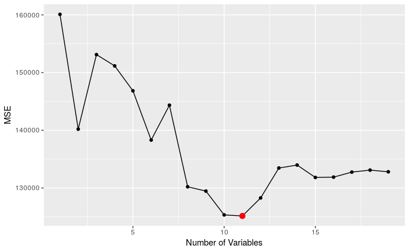

```r
# Plot the MSE for all 19 variables (model sizes)
pt_cv <- which.min(mean_cv_errors)
ggplot2::qplot(seq_along(mean_cv_errors),
               mean_cv_errors, ylab = "MSE",
               xlab = "Number of Variables") +
  geom_line() +
  geom_point(aes(x = pt_cv, y = mean_cv_errors[pt_cv]),
                 size = 3, colour = "red")
```

```r
# The 11 variable model has the lowest MSE
leaps::regsubsets(Salary ~ ., data = Hitters, nvmax = 19) %>%
  coef(pt_cv)
```

```
 (Intercept)        AtBat         Hits        Walks       CAtBat        CRuns         CRBI
 135.7512195   -2.1277482    6.9236994    5.6202755   -0.1389914    1.4553310    0.7852528
      CWalks      LeagueN    DivisionW      PutOuts      Assists
  -0.8228559   43.1116152 -111.1460252    0.2894087    0.2688277
```

# 3 Shrinkage methods: Ridge Regression

We redefine the `Hitters` data set to include only the model matrix `x` containing features (predictors) and a separate `y` variable for the `Response` (Salary).

```r
x <- model.matrix(Salary ~ ., Hitters)[, -1]   # remove Intercept column
head(x, 10)
```

```
   AtBat Hits HmRun Runs RBI Walks Years CAtBat CHits CHmRun CRuns CRBI CWalks LeagueN
1    315   81     7   24  38    39    14   3449   835     69   321  414    375       1
2    479  130    18   66  72    76     3   1624   457     63   224  266    263       0
3    496  141    20   65  78    37    11   5628  1575    225   828  838    354       1
4    321   87    10   39  42    30     2    396   101     12    48   46     33       1
5    594  169     4   74  51    35    11   4408  1133     19   501  336    194       0
6    185   37     1   23   8    21     2    214    42      1    30    9     24       1
7    298   73     0   24  24     7     3    509   108      0    41   37     12       0
8    323   81     6   26  32     8     2    341    86      6    32   34      8       1
9    401   92    17   49  66    65    13   5206  1332    253   784  890    866       0
10   574  159    21  107  75    59    10   4631  1300     90   702  504    488       0
   DivisionW PutOuts Assists Errors NewLeagueN
1          1     632      43     10          1
2          1     880      82     14          0
3          0     200      11      3          1
4          0     805      40      4          1
5          1     282     421     25          0
6          0      76     127      7          0
7          1     121     283      9          0
8          1     143     290     19          1
9          0       0       0      0          0
10         0     238     445     22          0
```

```r
y <- Hitters$Salary  # Salary is the Response variable we're predicting
summary(y)           # S3 method for numerics
```

```
   Min. 1st Qu.  Median    Mean 3rd Qu.    Max.
   67.5   190.0   425.0   535.9   750.0  2460.0
```

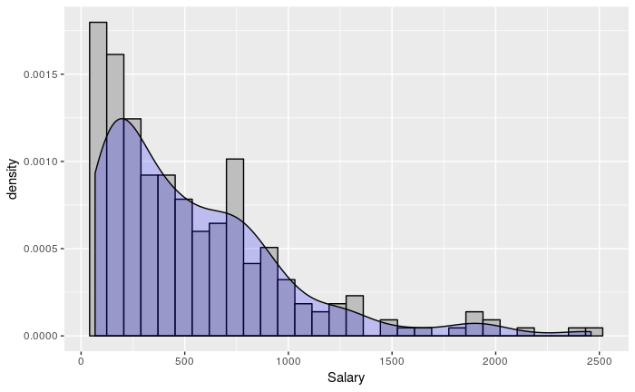

```r
y %>% data.frame() %>%
  magrittr::set_names("Salary") %>%     # rename `y` for the plot
  ggplot(aes(x = Salary)) +
  geom_histogram(aes(y = ..density..), fill = "gray", colour = "black") +
  geom_density(alpha = 0.2, fill = "blue")
```

## 3.1 Range of smoothing parameters

Perform a sweep across the tuning parameter `lambda` using the `glmnet::glmnet()` function.

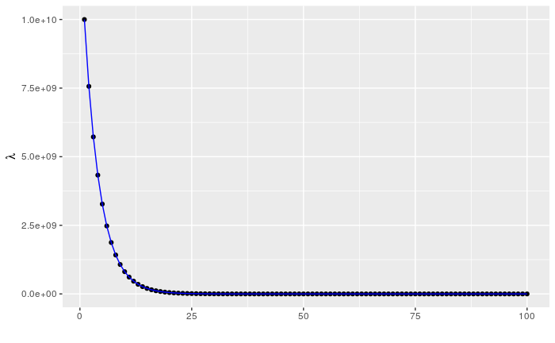

```r
# lambda = 10^{10} effectively reduces the model to the mean; upper extreme
# lambda = 10^{-2} is effectively linear regression; lower extreme
grid <- 10^seq(10, -2, length = 100)
ggplot2::qplot(x = seq_along(grid), y = grid,
               ylab = expression(lambda),
               xlab = "") +
  geom_line(colour = "blue")
```

```r
# Note:
# alpha is the elastic net parameter, alpha in [0,1]
# alpha = 0 selects ridge regression
# alpha = 1 selects lasso
ridge_model1 <- glmnet(x, y, alpha = 0, lambda = grid)

# Matrix of coefficients for each value of penalty parameter
dim(coef(ridge_model1))
```

```
[1]  20 100
```

```r
class(ridge_model1)
```

```
[1] "elnet"  "glmnet"
```

```r
# Select the 50th value of the penalty parameter lambda
# It is also the 50th value of `grid` we defined up front
ridge_model1$lambda[50]
```

```
[1] 11497.57
```

```r
coef(ridge_model1)[, 50]
```

```
  (Intercept)         AtBat          Hits         HmRun          Runs           RBI
407.356050200   0.036957182   0.138180344   0.524629976   0.230701523   0.239841459
        Walks         Years        CAtBat         CHits        CHmRun         CRuns
  0.289618741   1.107702929   0.003131815   0.011653637   0.087545670   0.023379882
         CRBI        CWalks       LeagueN     DivisionW       PutOuts       Assists
  0.024138320   0.025015421   0.085028114  -6.215440973   0.016482577   0.002612988
       Errors    NewLeagueN
 -0.020502690   0.301433531
```

```r
sqrt(sum(coef(ridge_model1)[-1, 50]^2))
```

```
[1] 6.360612
```

```r
# sqrt(sum(coef(ridge_model1)[2:20, 50]^2))

# Select the 60th value of the penalty parameter lambda
# This value should be smaller as lambda decreases
ridge_model1$lambda[60]
```

```
[1] 705.4802
```

```r
coef(ridge_model1)[, 60]
```

```
 (Intercept)        AtBat         Hits        HmRun         Runs          RBI        Walks
 54.32519950   0.11211115   0.65622409   1.17980910   0.93769713   0.84718546   1.31987948
       Years       CAtBat        CHits       CHmRun        CRuns         CRBI       CWalks
  2.59640425   0.01083413   0.04674557   0.33777318   0.09355528   0.09780402   0.07189612
     LeagueN    DivisionW      PutOuts      Assists       Errors   NewLeagueN
 13.68370191 -54.65877750   0.11852289   0.01606037  -0.70358655   8.61181213
```

```r
sqrt(sum(coef(ridge_model1)[-1, 60]^2))
```

```
[1] 57.11001
```

```r
# Find coefficients for penalty parameter (lambda) = 50; `s = `
predict(ridge_model1, s = 50, type = "coefficients")[1:20, ]
```

```
  (Intercept)         AtBat          Hits         HmRun          Runs           RBI
 4.876610e+01 -3.580999e-01  1.969359e+00 -1.278248e+00  1.145892e+00  8.038292e-01
        Walks         Years        CAtBat         CHits        CHmRun         CRuns
 2.716186e+00 -6.218319e+00  5.447837e-03  1.064895e-01  6.244860e-01  2.214985e-01
         CRBI        CWalks       LeagueN     DivisionW       PutOuts       Assists
 2.186914e-01 -1.500245e-01  4.592589e+01 -1.182011e+02  2.502322e-01  1.215665e-01
       Errors    NewLeagueN
-3.278600e+00 -9.496680e+00
```

```r
# Exercise: Show x = 50 is bracketed by the 69th and 70th penalties
# coef(ridge_model1)[, 69]
# ridge_model1$lambda[70]
# coef(ridge_model1)[, 70]
# ridge_model1$lambda[69]
```

## 3.2 Cross validation

We now split the `Hitters` (now `x`) data set into a **training** and **test** set to get a better estimate of how the model might perform on samples it has not *“seen”* and/or trained on.

```r
# Create training and test sets as above
set.seed(1)
n      <- nrow(x)            # number of total samples
train  <- sample(1:n, n/2)   # numeric indices; no replacement
test   <- -train             # negate with -ve, when indexing row is removed
y_test <- y[test]

# Estimating the test error via `glmnet`
ridge_model2 <- glmnet::glmnet(x[train, ], y[train],  # subset `x` into training set
                               alpha  = 0,            # ridge-regression alpha = 0
                               lambda = grid,         # use same grid as above
                               thresh = 1e-12)
ridge_pred <- predict(ridge_model2,            # S3 glmnet predict function
                      s = 4,                   # set lambda = 4
                      newx = x[test, ])        # subset `x` into test set

mean((ridge_pred - y_test)^2)                  # Calculate test MSE
```

```
[1] 101036.8
```

```r
# Exploring limits: large lambda vs mean of the training data
mean((mean(y[train]) - y_test)^2)
```

```
[1] 193253.1
```

```r
# An extremely large penalty essentially reduces beta_1 to beta_p to be zero
# i.e., the prediction becomes the mean for all predictors
ridge_pred2 <- predict(ridge_model2, s = 1e10, newx = x[test, ])
mean((ridge_pred2 - y_test)^2)             # MSE
```

```
[1] 193253.1
```

## 3.3 Exploring limits

```r
# Exploring limits: zero lambda vs linear regression
ridge_pred3 <- predict(ridge_model2,
                       s = 0,             # lambda = 0; un-penalized; see `lm()`
                       newx = x[test, ])  # subset to test set
mean((ridge_pred3 - y_test)^2)            # calculate test MSE
```

```
[1] 114723.6
```

```r
# Compare results with simple linear model without penalty
stats::lm(y ~ x, subset = train)          # better output for un-penalized model
```

```
Call:
stats::lm(formula = y ~ x, subset = train)

Coefficients:
(Intercept)       xAtBat        xHits       xHmRun        xRuns         xRBI       xWalks
  299.42849     -2.54027      8.36682     11.64512     -9.09923      2.44105      9.23440
     xYears      xCAtBat       xCHits      xCHmRun       xCRuns        xCRBI      xCWalks
  -22.93673     -0.18154     -0.11598     -1.33888      3.32838      0.07536     -1.07841
   xLeagueN   xDivisionW     xPutOuts     xAssists      xErrors  xNewLeagueN
   59.76065    -98.86233      0.34087      0.34165     -0.64207     -0.67442
```

```r
# Use type = 'coefficients' to return coeffs
# Note: very close approximation to the linear model with least squares
predict(ridge_model2, s = 0, type = "coefficients")[1:20, ]
```

```
 (Intercept)        AtBat         Hits        HmRun         Runs          RBI        Walks
299.44467220  -2.53538355   8.33585019  11.59830815  -9.05971371   2.45326546   9.21776006
       Years       CAtBat        CHits       CHmRun        CRuns         CRBI       CWalks
-22.98239583  -0.18191651  -0.10565688  -1.31721358   3.31152519   0.06590689  -1.07244477
     LeagueN    DivisionW      PutOuts      Assists       Errors   NewLeagueN
 59.75587273 -98.94393005   0.34083276   0.34155445  -0.65312471  -0.65882930
```

## 3.4 K-fold cross-validation

It is better to use cross-validation to estimate *best* lambda. Luckily, there is a build in function `glmnet::cv.glmnet` provided for this purpose. By default, `K = 10` cross-validation is performed.

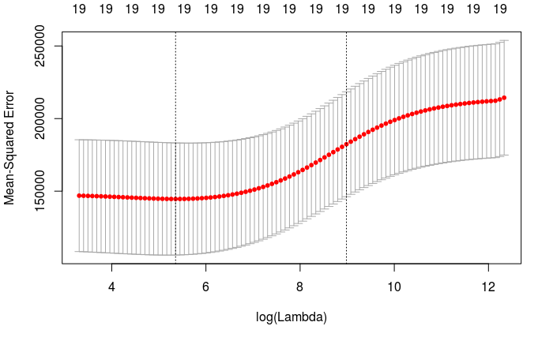

```r
set.seed(1)
ridge_cv <- cv.glmnet(x[train, ],  # subset training `predictor matrix`
                      y[train],    # subset training `response vector`
                      alpha = 0)   # ridge on training set

# Plot MSE vs the lambda penalty sweep
plot(ridge_cv)            # S3 plot method for class `cv.glmnet`
```

```r
# Store min lambda*
# Compare to the plot ... remember to log-transform!
lambda_star <- ridge_cv %>% purrr::pluck("lambda.min")
lambda_star
```

```
[1] 211.7416
```

```r
#
ridge_pred4 <- predict(ridge_model2,       # model fit on training set only
                       s = lambda_star,    # use lambda*
                       newx = x[test, ])   # predict on test set only
mean((ridge_pred4 - y_test)^2)             # calculate test MSE
```

```
[1] 96015.51
```

```r
# Now that we know lambda*, fit on *full* data set
full_fit_ridge <- glmnet::glmnet(x, y, alpha = 0)
predict(full_fit_ridge, type = "coefficients", s = lambda_star)[1:20, ]
```

```
 (Intercept)        AtBat         Hits        HmRun         Runs          RBI        Walks
  9.88487157   0.03143991   1.00882875   0.13927624   1.11320781   0.87318990   1.80410229
       Years       CAtBat        CHits       CHmRun        CRuns         CRBI       CWalks
  0.13074383   0.01113978   0.06489843   0.45158546   0.12900049   0.13737712   0.02908572
     LeagueN    DivisionW      PutOuts      Assists       Errors   NewLeagueN
 27.18227527 -91.63411282   0.19149252   0.04254536  -1.81244470   7.21208394
```

# 4 Shrinkage methods: The Lasso

## 4.1 Range of smoothing parameters

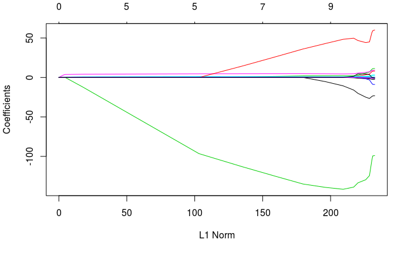

```r
lasso_model <- glmnet::glmnet(x[train, ],      # subset training `predictor matrix`
                              y[train],        # subset training `response vector`
                              alpha = 1,       # now alpha = 1; lasso
                              lambda = grid)   # same lambda search grid

# Plot coefficients as a function of penalty parameter using
# built-in S3 plot method
plot(lasso_model)
```

## 4.2 K-fold cross validation

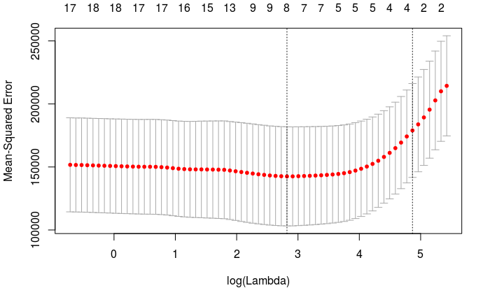

```r
# Once again, use k-fold cross validation (default K = 10)
set.seed(1)
lasso_cv <- glmnet::cv.glmnet(x[train, ], y[train], alpha = 1)

# Plot CV output
plot(lasso_cv)
```

```r
lambda_star2 <- lasso_cv %>%
  purrr::pluck("lambda.min")
lasso_pred   <- predict(lasso_model,        # Training set fitted model
                        s = lambda_star2,   # Predict using lambda*
                        newx = x[test, ])   # Predict on test set
mean((lasso_pred - y_test)^2)               # Calculate test MSE
```

```
[1] 100743.4
```

```r
# Now that we know lambda*, fit on *full* data set
full_fit_lasso <- glmnet(x, y, alpha = 1, lambda = grid)
lasso_coeffs   <- predict(full_fit_lasso,        # glmnet fit on full data
                         type = "coefficients",  # return betas; not predictions
                         s = lambda_star2)[1:20, ]
lasso_coeffs
```

```
 (Intercept)        AtBat         Hits        HmRun         Runs          RBI        Walks
  18.5394844    0.0000000    1.8735390    0.0000000    0.0000000    0.0000000    2.2178444
       Years       CAtBat        CHits       CHmRun        CRuns         CRBI       CWalks
   0.0000000    0.0000000    0.0000000    0.0000000    0.2071252    0.4130132    0.0000000
     LeagueN    DivisionW      PutOuts      Assists       Errors   NewLeagueN
   3.2666677 -103.4845458    0.2204284    0.0000000    0.0000000    0.0000000
```

```r
# Some Betas (coeffs) are zero as expected.
# Remove them to get a better look at the model
lasso_coeffs %>%
  magrittr::extract(. != 0)
```

```
 (Intercept)         Hits        Walks        CRuns         CRBI      LeagueN    DivisionW
  18.5394844    1.8735390    2.2178444    0.2071252    0.4130132    3.2666677 -103.4845458
     PutOuts
   0.2204284
```

Created on 2018-12-05 by the [Rmarkdown package](https://github.com/rstudio/rmarkdown) (v1.10) and R version 3.5.1 (2018-07-02).